# Golden Flower

1 炸金花概率分析

1.1 牌的构造和编码

1.2 游戏逻辑

1.3 牌面编码

1.4 穷举法

1.4.1 单人局

1.4.2 双人局

1.4.3 穷举法的复杂度

1.5 蒙特卡罗方法

1.5.1 2人

1.5.2 多人

1.6 近似计算方法

1.7 总结

1.7.1 概率

1.7.2 方法

# 炸金花概率分析

```python
# %load D:\Programs\Anaconda3\scilab.py
import numpy as np
from numpy import array, exp, sin, cos, tan, sqrt, r_, c_

import pandas as pd
from pandas import DataFrame, Series

import matplotlib.pyplot as plt
plot = plt.plot

import seaborn as sb

np.set_printoptions(precision=4)  #, suppress=True)
```

```python
%matplotlib inline
```

## 牌的构造和编码

```python
AllCards = (r_['0,2', 1j, 2j, 3j, 4j] + r_[2:15]).flatten()
AllCards
```

```
array([  2.+1.j,   3.+1.j,   4.+1.j,   5.+1.j,   6.+1.j,   7.+1.j,
         8.+1.j,   9.+1.j,  10.+1.j,  11.+1.j,  12.+1.j,  13.+1.j,
        14.+1.j,   2.+2.j,   3.+2.j,   4.+2.j,   5.+2.j,   6.+2.j,
         7.+2.j,   8.+2.j,   9.+2.j,  10.+2.j,  11.+2.j,  12.+2.j,
        13.+2.j,  14.+2.j,   2.+3.j,   3.+3.j,   4.+3.j,   5.+3.j,
         6.+3.j,   7.+3.j,   8.+3.j,   9.+3.j,  10.+3.j,  11.+3.j,
        12.+3.j,  13.+3.j,  14.+3.j,   2.+4.j,   3.+4.j,   4.+4.j,
         5.+4.j,   6.+4.j,   7.+4.j,   8.+4.j,   9.+4.j,  10.+4.j,
        11.+4.j,  12.+4.j,  13.+4.j,  14.+4.j])
```

```python
len(AllCards)
```

```
52
```

实部表牌面大小，A尖映射到14，序数属性；虚部表花色，标称属性。  
52张，不含大小王。

## 游戏逻辑

判断是否是该牌型

```python
def isBomb(a, b, c):  #炸弹
    return a.real == b.real == c.real
```

```python
def isPair(a, b, c):  #对子
    a = a.real
    b = b.real
    c = c.real
    return a == b or b == c or c == a
```

```python
def isStraight(a, b, c):  #顺子
    a, b, c = sorted([a.real, b.real, c.real], reverse=True)
    return (a == b + 1 and b == c + 1) or (a, b, c) == (14, 3, 2)
```

```python
def isFlush(a, b, c):  #同花
    return a.imag == b.imag == c.imag
```

```python
def isStraightFlush(a, b, c):  #同花顺
    return isFlush(a, b, c) and isStraight(a, b, c)
```

在某牌型中按重要性降序排序三张牌。

```python
def sortBomb(*cds):
    return np.real(cds)
```

```python
def sortPair(a, b, c):
    a = a.real
    b = b.real
    c = c.real
    if a == b:
        return a, b, c
    elif b == c:
        return b, c, a
    elif c == a:
        return a, c, b
    else:
        return None
```

```python
def sortStraight(a, b, c):
    a, b, c = sorted([a.real, b.real, c.real], reverse=True)
    if (a, b, c) == (14, 3, 2):
        return 3, 2, 14
    else:
        return a, b, c
```

```python
def sortSingle(a, b, c):
    return sorted([a.real, b.real, c.real], reverse=True)
```

```python
def sortFlush(a, b, c):
    return sortSingle(a, b, c)
```

```python
def sortStraightFlush(a, b, c):
    return sortStraight(a, b, c)
```

## 牌面编码

```python
def getType(*cds):
    if isBomb(*cds):
        return 5
    elif isFlush(*cds):
        if isStraight(*cds):
            return 4
        else:
            return 3
    elif isStraight(*cds):
        return 2
    elif isPair(*cds):
        return 1
    else:
        return 0
```

```python
TypeNames = ['Single', 'Pair', 'Straight', 'Flush', 'StraightFlush', 'Bomb']
```

为三张牌组成的牌面生成编码，有序编码，即小牌码小、大牌码大。

```python
wei = (16, 13, 13, 1)
bias = (0, -2, -2, -2)
```

```python
def encode(*cds):
    if isBomb(*cds):
        c = 5, sortBomb(*cds)

    elif isFlush(*cds):
        if isStraight(*cds):
            c = 4, sortStraight(*cds)

        else:
            c = 3, sortFlush(*cds)

    elif isStraight(*cds):
        c = 2, sortStraight(*cds)

    elif isPair(*cds):
        c = 1, sortPair(*cds)

    else:
        c = 0, sortSingle(*cds)

    c0, (c1, c2, c3) = c
    w0, w1, w2, w3 = wei
    b0, b1, b2, b3 = bias
    return int(
        ((((c0 + b0) * w0 + c1 + b1) * w1 + c2 + b2) * w2 + c3 + b3) * w3)
```

```python
def decode(c):
    ci = []
    for i in range(len(wei) - 1, 0, -1):
        c = c // wei[i]
        ci.append(c % wei[i - 1] - bias[i])
    ci.append(c // wei[0])
    s = TypeNames[ci[-1]] + ': ' + '%s' % ci[-2::-1]
    return s
```

```python
decode(encode(2 + 2j, 14 + 2j, 3 + 2j))
```

```
'StraightFlush: [3, 2, 14]'
```

## 穷举法

### 单人局

单人不成局，实际上是从52张中任取3张，这也代表了任意玩家数时桌面上所有牌面的分布情况。

```python
from itertools import combinations
```

```python
weightList = []
for cards in combinations(AllCards, 3):
    weightList.append(encode(*cards))
```

```python
weightList = np.sort(array(weightList))
```

```python
len(weightList)
```

```
22100
```

```python
weightList
```

```
array([  520,   520,   520, ..., 15716, 15716, 15716])
```

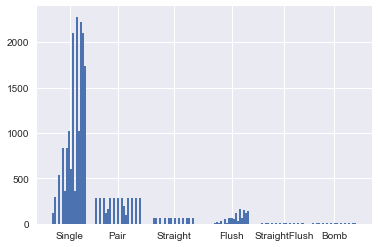

```python
plt.hist(weightList, bins=150)
plt.xticks((1400, 3800, 6600, 9500, 12100, 14600), TypeNames);
```

按牌面大小的整体分布，分别为：散、对、顺子、同花、同花顺、豹子

```python
res_1 = [0] * 6
for cards in combinations(AllCards, 3):
    res_1[getType(*cards)] += 1
```

```python
res_1 = array(res_1)
res_1
```

```
array([16440,  3744,   720,  1096,    48,    52])
```

```python
trueRate_1 = res_1 / res_1.sum()
trueRate_1
```

```
array([ 0.7439,  0.1694,  0.0326,  0.0496,  0.0022,  0.0024])
```

| 类型 | 总数 | 比重 |
| --- | --- | --- |
| 散 | 16440 | 74.39% |
| 对 | 3744 | 16.94% |
| 顺子 | 720 | 3.26% |
| 同花 | 1096 | 4.96% |
| 同花顺 | 48 | 0.22% |
| 豹子 | 52 | 0.24% |

按稀有度，顺子比同花稀有，同花顺比豹子稀有，虽然规定是同花及豹子更大。

```python
decode(max(weightList)), decode(min(weightList))
```

```
('Bomb: [14, 14, 14]', 'Single: [5, 3, 2]')
```

```python
def bigerRate(a, b, c):
    w = encode(a, b, c)
    return (weightList < w).sum() / len(weightList)
```

```python
bigerRate(14, 13, 3 + 3j)
```

```
0.71945701357466063
```

### 双人局

$n$人局情况，解决思路是先取出$n$个人的牌，然后再分给他们，则总情况数是 $$C_{52}^{3n}\cdot C_{3n}^{3}C_{3n-3}^{3}C_{3n-6}^{3}\cdots C_{6}^{3}C_{3}^{3}$$ 第一项是组合数，后面是分配数。

需要先实现每种分配情况的枚举：

```python
class sList(list):
    '支持差集运算的lsit'
    def __sub__(self, oth):
        return sList([x for x in self if x not in oth])
```

```python
def dist(l, segs):
    '''
    把l按segs分配len(segs)f份
    l: list
    segs: 每份容量大小组成的tuple
    return: 结果tuple的迭代器
    '''
    getResult = lambda ind: tuple(tuple(l[x] for x in L) for L in ind)
    length = len(l)
    assert (length == sum(segs))
    ind = sList(range(length))
    pools = []
    subLists = []
    result = []
    for i, seg in enumerate(segs):
        if i == 0:
            subLists.append(ind)
            pools.append(combinations(subLists[i], seg))
            result.append(sList(next(pools[i])))
        else:
            subLists.append(subLists[i - 1] - result[i - 1])
            pools.append(combinations(subLists[i], seg))
            result.append(sList(next(pools[i])))

    while True:
        yield getResult(result)

        for i, pool in reversed(list(enumerate(pools))):
            try:
                re = sList(next(pool))
                result[i] = re
                try:
                    for rei in range(i + 1, len(segs)):
                        subLists[rei] = subLists[rei - 1] - result[rei - 1]
                        pools[rei] = combinations(subLists[rei], segs[rei])
                        result[rei] = sList(next(pools[rei]))
                except:
                    assert (False)
                break
            except StopIteration:
                if i == 0:
                    return
                else:
                    continue
```

```python
gg = dist([1, 2, 3, 4], (1, 2, 1))
```

```python
*gg,
```

```
(((1,), (2, 3), (4,)),
 ((1,), (2, 4), (3,)),
 ((1,), (3, 4), (2,)),
 ((2,), (1, 3), (4,)),
 ((2,), (1, 4), (3,)),
 ((2,), (3, 4), (1,)),
 ((3,), (1, 2), (4,)),
 ((3,), (1, 4), (2,)),
 ((3,), (2, 4), (1,)),
 ((4,), (1, 2), (3,)),
 ((4,), (1, 3), (2,)),
 ((4,), (2, 3), (1,)))
```

以下计算全场最大是某类型牌的概率

```python
# 运行时间很长
res_2 = [0] * 6
run = False
if run:
    for cards in combinations(AllCards, 6):
        for cds1, cds2 in dist(cards, (3, 3)):
            res_2[max(getType(*cds1), getType(*cds2))] += 1
```

```python
res_2
```

```
[0, 0, 0, 0, 0, 0]
```

某次运行结果：

```python
aRes_2 = array([225461472, 114200640, 24657792, 39174400, 1762496, 1913600])  #某次运行结果
```

```python
trueRate_2 = aRes_2 / aRes_2.sum()
trueRate_2
```

```
array([ 0.5537,  0.2805,  0.0606,  0.0962,  0.0043,  0.0047])
```

| 最大牌 | 单人 | 双人 |
| --- | --- | --- |
| 散 | 74.39% | 55.37% |
| 对 | 16.94% | 28.05% |
| 顺子 | 3.26% | 6.06% |
| 同花 | 4.96% | 9.62% |
| 同花顺 | 0.22% | 0.43% |
| 豹子 | 0.24% | 0.47% |

### 穷举法的复杂度

如上所述，$n$人局总情况数为： $$C_{52}^{3n}\cdot C_{3n}^{3}C_{3n-3}^{3}C_{3n-6}^{3}\cdots C_{6}^{3}C_{3}^{3}$$

```python
from scipy.special import comb
```

```python
from functools import reduce
```

```python
def complication(n):
    rdFun = lambda x, y: x * comb(y, 3)
    li = list(range(6, 6 + 3 * (n - 2) + 1, 3))
    cb = comb(52, 3 * n)
    li = [cb] + li
    #print(li)
    return cb, reduce(rdFun, li)
```

```python
complication(3)
```

```
(3679075400.0, 6180846672000.0)
```

```python
comb(52, 9) * comb(6, 3) * comb(9, 3)
```

```
6180846672000.0
```

或者化简后有：
$$\frac{52!}{6^n(52-(3n)!)}$$

```python
from math import factorial
```

```python
complication2 = lambda n: factorial(52) / (6**n * factorial(52 - 3 * n))
```

```python
complication2(3)
```

```
6180846672000.0
```

结果一样

```python
cp = [complication(i)[1] for i in range(1, 52 // 3 + 1)]  #复杂度
cb = [complication(i)[0] for i in range(1, 52 // 3 + 1)]  #其中组合数部分
di = ([cp / cb for cb, cp in zip(cb, cp)])  #其中分配数部分
```

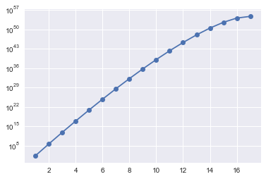

```python
plot(r_[1:18], cp, '-o')
plt.yscale('log')
```

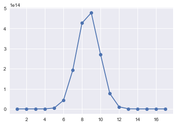

```python
plot(r_[1:18], cb, '-o');
```

组合数comb(54,n*3)先升后降

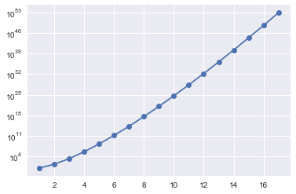

```python
plot(r_[1:18], di, '-o')
plt.yscale('log')
```

分配数增长快于指数

估计计算耗时：

```python
%%timeit -o
res_t = [0] * 6
for cards in combinations(AllCards[:15], 6):
    for cds1, cds2 in dist(cards, (3, 3)):
        res_t[max(getType(*cds1), getType(*cds2))] += 1
```

```
1 loop, best of 3: 1.6 s per loop
```

```
<TimeitResult : 1 loop, best of 3: 1.6 s per loop>
```

```python
spc = _.best / (comb(15, 6) * comb(6, 3))  #秒/状态
```

```python
cp=array(cp)
```

```python
cp[0] * spc, cp[1] * spc / 3600  #秒，小时
```

```
(0.3540750035791157, 1.8120771849837853)
```

可以看到上面穷举双人局需要的时间

```python
years = cp * spc / 3600 / 24 / 365
years  #所需年数
```

```
array([  1.1228e-08,   2.0686e-04,   3.1401e+00,   3.8752e+04,
         3.8287e+08,   2.9749e+12,   1.7802e+16,   8.0019e+19,
         2.6214e+23,   6.0293e+26,   9.2851e+29,   8.9973e+32,
         5.0385e+35,   1.4410e+38,   1.7292e+40,   6.0522e+41,   2.4209e+42])
```

sec, h, years, 万年, 亿年 ... 10^40+ years

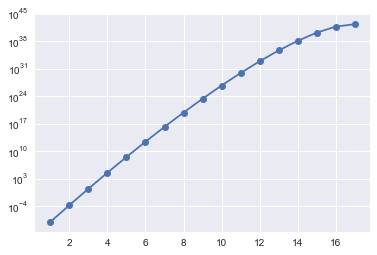

```python
plot(r_[1:18], years, '-o')
plt.yscale('log')
```

## 蒙特卡罗方法

也是计算全场最大是某类型牌的概率

```python
def choiceCards(cards, n):
    return np.random.choice(cards,size=n,replace=False)
```

```python
def biggest(cardsList): #返回全场最大牌的类型
    typeList = [getType(*cards) for cards in cardsList]
    return max(typeList)
```

```python
def oneTrial(cards, num_people):
    cds = choiceCards(cards, 3*num_people)
    cdsList = np.split(cds,num_people)
    #print(cdsList)
    re=[0]*6
    re[biggest(cdsList)]=1 #one-hot
    return re
```

```python
class MonteCarlo:
    '''
    进行蒙特卡洛试验的类\n
    子类需重载以下property:
        n_samples: int, 试验总样本数，当且仅当试验过后有＞0
        rate: float 1D-array, 当前概率（频率），长度为随机变量数目
        X: float 1D-array, 记录历史样本数变化，用于绘图时x轴
        rateHistory: float 2D-array, shape(len(X), len(rate)), 记录历史概率变化，对应于X，用于绘图\n
    子类需重载以下方法:
        trial(self, times)
    '''

    def __init__(self, varNames, accuracy=None):
        '''varNames: str list. 各随机变量的名称，用于绘图标注
        accuracy: float, autoFit()的目标精度
        '''
        self.accuracy = accuracy  #训练的目标精度
        self.varNames = varNames

    #需重载
    n_samples = property(None)
    rate = property(None)

    X = property(None)
    rateHistory = property(None)

    def trial(self, times):
        '''
        需重载
        调用时进行times次试验
        会被autoFit多次调用，每次被调用可仅添加一个历史（更新一次X,rateHistory）
        '''
        pass

    def autoFit(self, accuracy=None, bunchLen=None, n_groups=100):
        '''
        accuracy: 目标精度
        bunchLen: 一次性训练数，作每次调用trial()时的参数
        n_groups: 大约分n_groups次训练，在bunchLen指定时被覆盖
        '''
        if accuracy:
            self.accuracy = accuracy
        else:
            self.accuracy = self.accuracy or 0.01
            accuracy = self.accuracy

        #估计总组样本数
        sizeFun = lambda r: int((r * (1 - r)).max() / (accuracy / 3)**2)

        if not self.n_samples > 0:
            self.trial()
        while not ((3 * self.sigma < accuracy).all()
                   and ((0 < self.sigma).all() or self.n_samples>10000)):
            #3-sigma准则，犯错概率小于0.3%
            n = bunchLen or sizeFun(self.rate) // n_groups or 1
            self.trial(n)
        return self

    def plotRate(self):
        plot(self.X, self.rateHistory)
        plt.yscale('log')
        plt.legend(self.varNames)
        plt.show()

    #当前标准差，长度为随机变量数目
    sigma = property(lambda sf: sqrt(sf.rate * (1 - sf.rate) / sf.n_samples))

    def getProgress(self):
        if self.n_samples > 0:
            return (self.accuracy / (3 * self.sigma.max()))**2
        else:
            return 0

    progress = property(getProgress)  #属于闭区间[0,1], 完成进度

    def isDone(self):
        return self.progress >= 1

    def __repr__(self):
        if not self.n_samples > 0:
            return 'Never fit.'
        else:
            return ('goal accuracy is %s,\t' % self.accuracy +
                    '%s trials yet, %.2f%% completed.' %
                    (self.n_samples, self.progress * 100) +
                    (self.isDone() and '   DONE!\n'
                     or '\n') + '3-sigma: %s, max: %.4g\n' %
                    (3 * self.sigma,
                     3 * self.sigma.max()) + 'rate is: %s' % self.rate)
```

从getProgress()和sizeFun()可以看出，蒙特卡罗方法复杂度随精度（误差分之一）增加呈平方上升，$O(n^2)$，多项式复杂度，可接受。

```python
class gfMon(MonteCarlo):
    '用于炸金花蒙特卡洛试验'
    def __init__(self, trialFun, names=TypeNames, accuracy=None):
        'trialFun: 调用返回‘one-hot’列表，如：[0,0,1,0,0,0]'
        MonteCarlo.__init__(self,names,accuracy)
        self.trialFun = trialFun
        self.trialList = []
        self.upToDate = False

    def trial(self, times=100):
        assert (times > 0)
        re = []
        for i in range(times):
            re.append(self.trialFun())
        self.trialList.append(np.sum(re,axis=0))
        self.upToDate = False
        return self

    def refresh(self):
        if self.trialList:
            tArr = array(self.trialList)
            cArr = tArr.cumsum(axis=0)
            self._X = cArr.sum(axis=1)
            sumVector = self._X.reshape(-1, 1)
            self._rateHis = cArr / sumVector
            self.upToDate = True
        else:
            self._X = [np.nan]
            self._rateHis = [np.nan]

    def getrateHistory(self):
        if not self.upToDate:
            self.refresh()
        return self._rateHis

    def getX(self):
        if not self.upToDate:
            self.refresh()
        return self._X

    X = property(getX)
    n_samples = property(lambda sf: sf.X[-1])
    rateHistory = property(getrateHistory)
    rate = property(lambda sf: sf.rateHistory[-1])
```

### 2人

```python
m2 = gfMon(lambda: oneTrial(AllCards, 2))
m2
```

```
Never fit.
```

```python
m2.autoFit(accuracy=0.01)
```

```
goal accuracy is 0.01,	22193 trials yet, 100.05% completed.   DONE!
3-sigma: [ 0.01    0.009   0.0048  0.0059  0.0013  0.0014], max: 0.009997
rate is: [ 0.5595  0.2768  0.0594  0.0955  0.0039  0.0048]
```

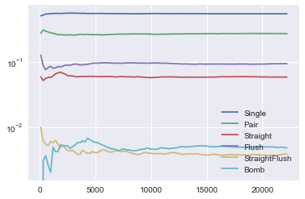

```python
m2.plotRate()
```

```python
trueRate_2
```

```
array([ 0.5537,  0.2805,  0.0606,  0.0962,  0.0043,  0.0047])
```

```python
trueRate_2 - m2.rate
```

```
array([-0.0058,  0.0037,  0.0012,  0.0007,  0.0004, -0.0001])
```

达到宣称精度